# Caracterización agroclimatica de Valle Central Intermontano

### author:

### - “Luis Arturo Arrieta” con apoyo de OpenAI. (2023)

# Cargar dataframes

# 2. Caracterización climática de la temperatura del aire.

## 1. Variación interanual de la temperatura máxima

### 1.3. Temperaturas máximas medias anuales por estación.

Temperatura máxima media anual en Aeropueto Juan Santa Maria

| Año | x |
| --- | --- |
| 1998 | 27.17368 |
| 1999 | 27.63973 |
| 2000 | 28.11452 |
| 2001 | 28.80760 |
| 2002 | 29.05543 |
| 2003 | 28.95912 |
| 2004 | 28.17079 |
| 2005 | 27.73156 |
| 2006 | 27.90240 |
| 2007 | 28.33025 |
| 2008 | 27.93799 |
| 2009 | 28.66747 |
| 2010 | 28.11390 |
| 2011 | 28.45398 |
| 2012 | 28.49408 |
| 2013 | 28.49961 |
| 2014 | 28.27630 |
| 2015 | 28.63034 |
| 2016 | 28.39794 |
| 2017 | 28.07845 |
| 2018 | 27.92955 |
| 2019 | 28.22011 |
| 2020 | 28.44839 |

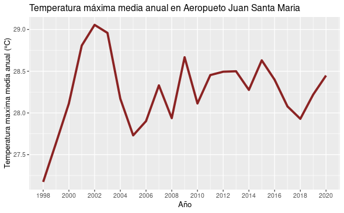

### 1.4. Temperatura máxima absoluta anual por estación.

Temperatura máxima absoluta anual en Aeropueto Juan Santa Maria

| Año | x |
| --- | --- |
| 1998 | 30.7 |
| 1999 | 31.5 |
| 2000 | 31.8 |
| 2001 | 32.8 |
| 2002 | 33.0 |
| 2003 | 33.2 |
| 2004 | 34.5 |
| 2005 | 33.4 |
| 2006 | 32.0 |
| 2007 | 33.0 |
| 2008 | 31.5 |
| 2009 | 32.8 |
| 2010 | 33.7 |
| 2011 | 32.8 |
| 2012 | 32.4 |
| 2013 | 32.9 |
| 2014 | 33.0 |
| 2015 | 33.0 |
| 2016 | 36.4 |
| 2017 | 33.4 |
| 2018 | 32.5 |
| 2019 | 33.8 |
| 2020 | 32.2 |

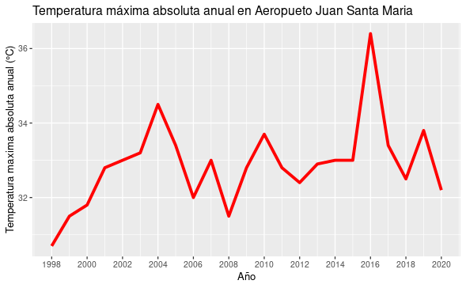

## 2. Variación interanual de la temperatura mínima

Por algún motivo, la estación meteorologica de SANTA_BARBARA registró -43.2 para la fecha 2013-07-27, vamos a reemplzar ese valor por un NA

| Date | DV | VV | TN | TM | HR | PP | RAD_MEA | SUNSHINE | Nombre_Base |
| --- | --- | --- | --- | --- | --- | --- | --- | --- | --- |
| 2013-07-27 | 3 | 3.1 | -43.19 | 21.5 | 72 | 5 | NA | 12.58833 | metdata_santabarbara |

Borrar dato

Revisar el cambio

| Date | TN | Nombre_Base |
| --- | --- | --- |
| 2013-07-27 | NA | metdata_Santamaria |
| 2013-07-27 | NA | metdata_santabarbara |

### 2.1. Temperaturas mínimas medias anuales en la región

Temperatura mínima media anual en Valle central Intermontano

| Año | x |
| --- | --- |
| 1998 | 18.24607 |
| 1999 | 17.96005 |
| 2000 | 18.23696 |
| 2001 | 18.50026 |
| 2002 | 18.09161 |
| 2003 | 17.91572 |
| 2004 | 17.87088 |
| 2005 | 17.61542 |
| 2006 | 17.69667 |
| 2007 | 17.50993 |
| 2008 | 17.23449 |
| 2009 | 17.88811 |
| 2010 | 18.17222 |
| 2011 | 17.42826 |
| 2012 | 17.36611 |
| 2013 | 17.30544 |
| 2014 | 17.11115 |
| 2015 | 17.41287 |
| 2016 | 17.01749 |
| 2017 | 16.75475 |
| 2018 | 16.44903 |
| 2019 | 16.64330 |
| 2020 | 16.63978 |

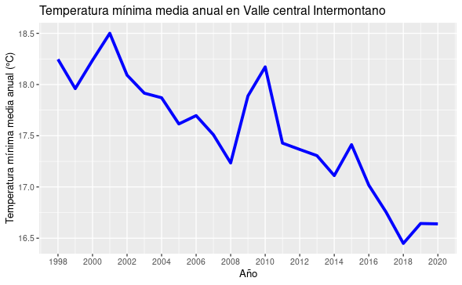

### 2.2. Temperatura mínima absoluta anual en la región.

Temperatura mínima absoluta anual en Valle central Intermontano

| Año | x |
| --- | --- |
| 1998 | 15.77 |
| 1999 | 14.09 |
| 2000 | 14.29 |
| 2001 | 11.96 |
| 2002 | 9.80 |
| 2003 | 10.37 |
| 2004 | 10.36 |
| 2005 | 11.05 |
| 2006 | 10.85 |
| 2007 | 11.05 |
| 2008 | 10.10 |
| 2009 | 12.07 |
| 2010 | 13.03 |
| 2011 | 10.49 |
| 2012 | 10.96 |
| 2013 | 11.03 |
| 2014 | 8.75 |
| 2015 | 10.57 |
| 2016 | 11.40 |
| 2017 | 9.10 |
| 2018 | 7.50 |
| 2019 | 10.20 |
| 2020 | 10.70 |

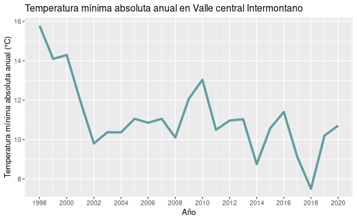

### 2.3. Temperaturas mínimas medias anuales por estación

#### 2.3.1 y 2.4.1 Estación Juan Santa María

Temperatura mínima media anual en el Aeropuerto Juan Santa María

| Año | x |
| --- | --- |
| 1998 | 18.24607 |
| 1999 | 17.96005 |
| 2000 | 18.23696 |
| 2001 | 18.77805 |
| 2002 | 19.35857 |
| 2003 | 19.03937 |
| 2004 | 18.87314 |
| 2005 | 18.50191 |
| 2006 | 18.70069 |
| 2007 | 18.58088 |
| 2008 | 18.23731 |
| 2009 | 18.91553 |
| 2010 | 18.84856 |
| 2011 | 18.52041 |
| 2012 | 18.61101 |
| 2013 | 18.64000 |
| 2014 | 18.89255 |
| 2015 | 19.05451 |
| 2016 | 18.34617 |
| 2017 | 17.91317 |
| 2018 | 17.90567 |
| 2019 | 18.11243 |
| 2020 | 18.47419 |

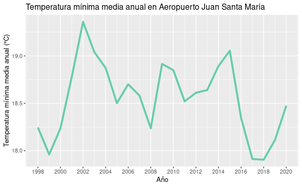

Temperatura mínima absoluta anual en Aeropuerto Juan Santa María

| Año | x |
| --- | --- |
| 1998 | 15.77 |
| 1999 | 14.09 |
| 2000 | 14.29 |
| 2001 | 14.29 |
| 2002 | 14.13 |
| 2003 | 15.16 |
| 2004 | 13.18 |
| 2005 | 13.83 |
| 2006 | 14.63 |
| 2007 | 14.20 |
| 2008 | 14.64 |
| 2009 | 14.95 |
| 2010 | 15.15 |
| 2011 | 14.47 |
| 2012 | 14.64 |
| 2013 | 14.51 |
| 2014 | 15.45 |
| 2015 | 13.70 |
| 2016 | 13.20 |
| 2017 | 11.80 |
| 2018 | 12.80 |
| 2019 | 13.90 |
| 2020 | 14.20 |

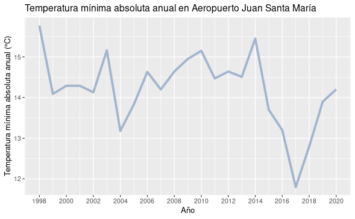

#### 2.3.2 y 2.4.2 Estación Santa Barbara

Temperatura mínima media anual en Santa Barbara

| Año | x |
| --- | --- |
| 2001 | 16.68964 |
| 2002 | 16.78047 |
| 2003 | 16.79515 |
| 2004 | 16.74099 |
| 2005 | 16.47610 |
| 2006 | 16.64026 |
| 2007 | 16.42103 |
| 2008 | 16.20293 |
| 2009 | 16.76869 |
| 2010 | 17.20333 |
| 2011 | 16.00728 |
| 2012 | 16.19793 |
| 2013 | 16.20142 |
| 2014 | 16.33887 |
| 2015 | 16.90033 |
| 2016 | 16.46231 |
| 2017 | 16.47658 |
| 2018 | 15.98137 |
| 2019 | 16.13425 |
| 2020 | 16.43226 |

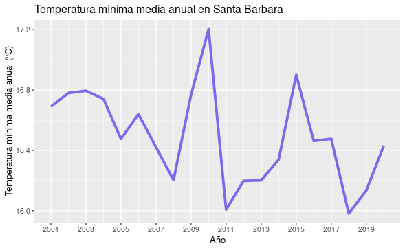

Temperatura mínima absoluta anual en Santa Barbara

| Año | x |
| --- | --- |
| 2001 | 11.96 |
| 2002 | 9.80 |
| 2003 | 10.37 |
| 2004 | 10.36 |
| 2005 | 11.05 |
| 2006 | 10.85 |
| 2007 | 11.05 |
| 2008 | 10.10 |
| 2009 | 12.07 |
| 2010 | 13.03 |
| 2011 | 10.49 |
| 2012 | 10.96 |
| 2013 | 11.73 |
| 2014 | 9.30 |
| 2015 | 11.53 |
| 2016 | 11.40 |
| 2017 | 11.20 |
| 2018 | 10.50 |
| 2019 | 10.30 |
| 2020 | 10.70 |

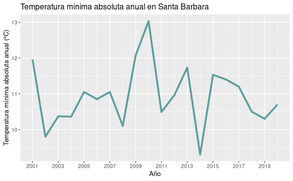

#### 2.3.3 y 2.4.3 Estación Naranjo

Temperatura mínima media anual en Naranjo

| Año | x |
| --- | --- |
| 2013 | 15.61074 |
| 2014 | 16.10203 |
| 2015 | 16.28207 |
| 2016 | 16.20000 |
| 2017 | 15.89836 |
| 2018 | 15.50795 |
| 2019 | 15.54375 |
| 2020 | 15.01290 |

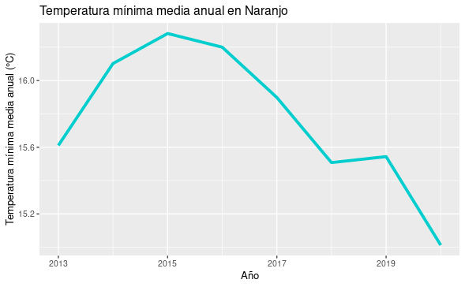

Temperatura mínima absoluta anual en Naranjo

| Año | x |
| --- | --- |
| 2013 | 11.03 |
| 2014 | 8.75 |
| 2015 | 10.57 |
| 2016 | 11.70 |
| 2017 | 9.10 |
| 2018 | 7.50 |
| 2019 | 10.20 |
| 2020 | 11.50 |

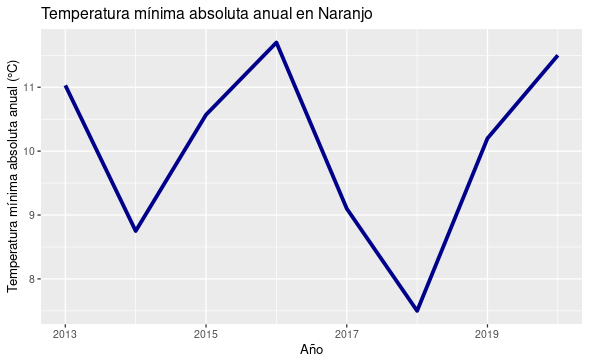

## 3. Variación interanual de la temperatura media

### 3.1. Temperaturas medias anuales en la región

Temperatura media anual en Valle central Intermontano

| Año | x |
| --- | --- |
| 1998 | 21.66842 |
| 1999 | 21.67945 |
| 2000 | 22.08443 |
| 2001 | 22.53905 |
| 2002 | 22.51300 |
| 2003 | 22.25644 |
| 2004 | 22.18428 |
| 2005 | 21.88970 |
| 2006 | 22.02968 |
| 2007 | 21.80359 |
| 2008 | 21.51415 |
| 2009 | 22.23590 |
| 2010 | 22.11683 |
| 2011 | 21.77714 |
| 2012 | 21.79174 |
| 2013 | 21.78993 |
| 2014 | 21.52203 |
| 2015 | 21.84146 |
| 2016 | 21.53925 |
| 2017 | 21.22249 |
| 2018 | 21.02082 |
| 2019 | 21.28426 |
| 2020 | 21.44839 |

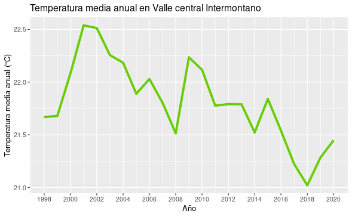

### 3.2. Temperaturas medias anuales por estación

#### 3.2.1 Estación Juan Santa María

Temperatura media anual en Aeropuerto Juan Santa María

| Año | x |
| --- | --- |
| 1998 | 21.66842 |
| 1999 | 21.67945 |
| 2000 | 22.08443 |
| 2001 | 22.70879 |
| 2002 | 23.14551 |
| 2003 | 22.82192 |
| 2004 | 22.68434 |
| 2005 | 22.20563 |
| 2006 | 22.51616 |
| 2007 | 22.33863 |
| 2008 | 22.05000 |
| 2009 | 22.71836 |
| 2010 | 22.35884 |
| 2011 | 22.20712 |
| 2012 | 22.44955 |
| 2013 | 22.56110 |
| 2014 | 22.74137 |
| 2015 | 22.76219 |
| 2016 | 22.17896 |
| 2017 | 21.68028 |
| 2018 | 21.65397 |
| 2019 | 21.96497 |
| 2020 | 22.18065 |

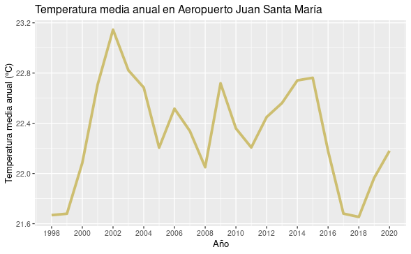

#### 3.2.2 Estación Santa Barbara

Temperatura media anual en Santa Barbara

| Año | x |
| --- | --- |
| 2001 | 21.43571 |
| 2002 | 21.85843 |
| 2003 | 21.69096 |
| 2004 | 21.62074 |
| 2005 | 21.48333 |
| 2006 | 21.51647 |
| 2007 | 21.25961 |
| 2008 | 20.95769 |
| 2009 | 21.71335 |
| 2010 | 21.76640 |
| 2011 | 21.21259 |
| 2012 | 21.17099 |
| 2013 | 21.32078 |
| 2014 | 21.44423 |
| 2015 | 21.83836 |
| 2016 | 21.60325 |
| 2017 | 21.35315 |
| 2018 | 21.09205 |
| 2019 | 21.36658 |
| 2020 | 21.58387 |

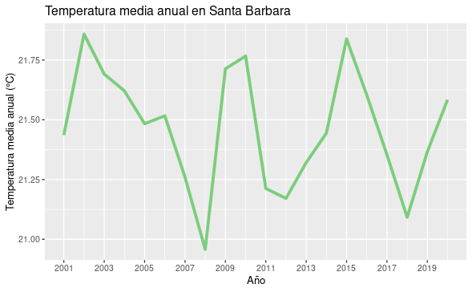

Temperatura media anual en Naranjo

| Año | x |
| --- | --- |
| 2013 | 19.94118 |
| 2014 | 20.38027 |
| 2015 | 20.92384 |
| 2016 | 20.84044 |
| 2017 | 20.64658 |
| 2018 | 20.31644 |
| 2019 | 20.39276 |
| 2020 | 20.58065 |

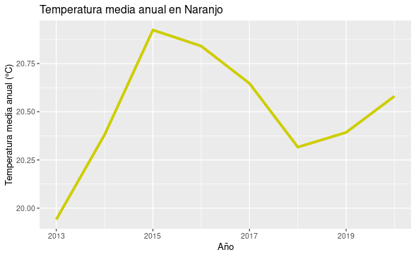

## 4. Amplitud térmica anual y climadiagramas por estación

### 4.1 Amplitud térmica anual

Amplitud térmica anual

| Año | temp_max | temp_min | amplitud_termica |
| --- | --- | --- | --- |
| 1998 | 27.17368 | 18.24607 | 8.927613 |
| 1999 | 27.63973 | 17.96005 | 9.679671 |
| 2000 | 28.11452 | 18.23696 | 9.877562 |
| 2001 | 28.80760 | 18.77805 | 10.029546 |
| 2002 | 29.05543 | 19.35857 | 9.696861 |
| 2003 | 28.95912 | 19.03937 | 9.919754 |
| 2004 | 28.17079 | 18.87314 | 9.297651 |
| 2005 | 27.73156 | 18.50191 | 9.229646 |
| 2006 | 27.90240 | 18.70069 | 9.201712 |
| 2007 | 28.33025 | 18.58088 | 9.749370 |
| 2008 | 27.93799 | 18.23731 | 9.700684 |
| 2009 | 28.66747 | 18.91553 | 9.751941 |
| 2010 | 28.11390 | 18.84856 | 9.265341 |
| 2011 | 28.45398 | 18.52041 | 9.933564 |
| 2012 | 28.49408 | 18.61101 | 9.883060 |
| 2013 | 28.49961 | 18.64000 | 9.859607 |
| 2014 | 28.27630 | 18.89255 | 9.383749 |
| 2015 | 28.63034 | 19.05451 | 9.575834 |
| 2016 | 28.39794 | 18.34617 | 10.051767 |
| 2017 | 28.07845 | 17.91317 | 10.165288 |
| 2018 | 27.92955 | 17.90567 | 10.023882 |
| 2019 | 28.22011 | 18.11243 | 10.107681 |
| 2020 | 28.44839 | 18.47419 | 9.974194 |

[figure not shown]

### 4.2 climadiagramas por estación

```r
library(readxl)
library(readr)
temperatura_maxima <- read_excel("temperatura_maxima.xlsx",
    col_types = c("date", "numeric"))
metdata_Santamaria <- read_csv("metdata_Santamaria.csv",
    col_types = cols(Date = col_date(format = "%Y-%m-%d"),
        DV = col_number(), VV = col_number(),
        TN = col_number(), TM = col_number(),
        HR = col_number(), PP = col_number(),
        RAD_MEA = col_number(), SUNSHINE = col_number()))
```

#### Agregar la columna mes al data frame

##### Generar tabla de entrada como le gusta a Climatol

## Agregar la temperatura maxima

## Agregar la temperatura minima promedio

### Borrar la columna “variable”

### Borrar la columna NA

##### Visualizar Tabla lista para usar climatol

Promedios mensuales de precipitaciones, temperatura maxima, minima y temperatura minima absoluta

| ENE | FEB | MAR | ABR | MAY | JUN | JUL | AGO | SEP | OCT | NOV | DIC |
| --- | --- | --- | --- | --- | --- | --- | --- | --- | --- | --- | --- |
| 0.2061584 | 0.3615514 | 0.4096774 | 2.39580 | 8.059055 | 7.480597 | 4.856984 | 6.776395 | 10.15523 | 9.703987 | 4.928145 | 1.053776 |
| 28.0167012 | 28.5297890 | 29.4114659 | 29.67344 | 28.650666 | 28.291431 | 28.199550 | 28.292826 | 28.11513 | 27.387830 | 27.430575 | 27.808053 |
| 18.4293979 | 18.3979730 | 18.6492923 | 19.06790 | 18.964525 | 18.887629 | 18.996365 | 18.610954 | 18.11955 | 18.206911 | 18.222159 | 18.370137 |
| 11.8000000 | 13.1800000 | 13.9200000 | 14.70000 | 14.510000 | 15.880000 | 15.160000 | 15.400000 | 15.00000 | 14.700000 | 14.530000 | 12.800000 |

### Paquete climatol

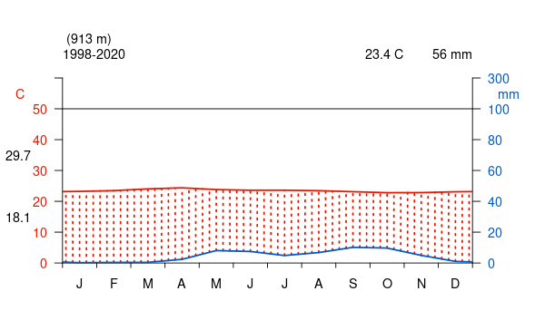

# 3. Caracterización climática de la precipitación.

##### Agregar la columna “month al data frame

Agregar mes

## Precipitación mensual media por estación

### Estación Aeropuerto Juan Santamaria

Promedios mensuales de precipitaciones estación Aeropuerto Juansantamaria

| month | PP |
| --- | --- |
| Jan | 0.2061584 |
| Feb | 0.3615514 |
| Mar | 0.4096774 |
| Apr | 2.3957997 |
| May | 8.0590551 |
| Jun | 7.4805970 |
| Jul | 4.8569841 |
| Aug | 6.7763955 |
| Sep | 10.1552288 |
| Oct | 9.7039872 |
| Nov | 4.9281447 |
| Dec | 1.0537764 |

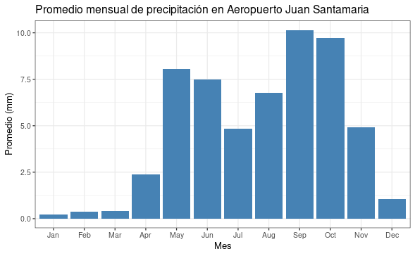

### Estación Santa Barbara

Promedios mensuales de precipitaciones estación Santa Barbara

| month | PP |
| --- | --- |
| Jan | 0.3817029 |
| Feb | 0.6230769 |
| Mar | 1.8722736 |
| Apr | 4.3555556 |
| May | 11.5956685 |
| Jun | 12.0342222 |
| Jul | 7.2307851 |
| Aug | 9.7646953 |
| Sep | 14.5771372 |
| Oct | 14.1247423 |
| Nov | 6.5618290 |
| Dec | 1.8323171 |

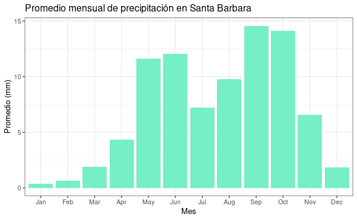

### Estación Naranjo

Promedios mensuales de precipitaciones estación Naranjo

| month | PP |
| --- | --- |
| Jan | 0.1537634 |
| Feb | 0.1900000 |
| Mar | 0.0451613 |
| Apr | 0.8245810 |
| May | 5.5896774 |
| Jun | 8.1333333 |
| Jul | 5.5247312 |
| Aug | 6.0822857 |
| Sep | 11.2893333 |
| Oct | 11.1666667 |
| Nov | 5.6720930 |
| Dec | 1.0258065 |

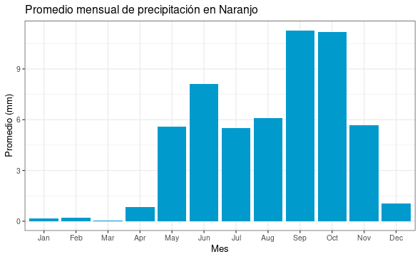

### Periodo total con precipitación mensual media por año en la Región

Promedios mensuales de precipitaciones Valle Central intermontano

| month | PP |
| --- | --- |
| Jan | 0.2675352 |
| Feb | 0.4434638 |
| Mar | 0.9551596 |
| Apr | 2.9765321 |
| May | 9.1909160 |
| Jun | 9.2653367 |
| Jul | 5.8363077 |
| Aug | 7.9131618 |
| Sep | 12.0479842 |
| Oct | 11.5729199 |
| Nov | 5.6525553 |
| Dec | 1.3357463 |

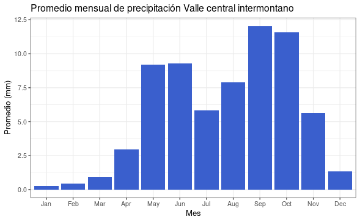

### Periodo total con precipitación mensual por año en cada estación

Periodo total con precipitación mensual por año en cada estación Valle Central intermontano

| month | PP |
| --- | --- |
| Jan | 379.9 |
| Feb | 532.6 |
| Mar | 1286.6 |
| Apr | 3982.6 |
| May | 12141.2 |
| Jun | 11146.2 |
| Jul | 7587.2 |
| Aug | 10761.9 |
| Sep | 15240.7 |
| Oct | 14743.9 |
| Nov | 7410.5 |
| Dec | 1789.9 |

[figure not shown]

### Precipitación anual media en la Región

#### Aeropuerto Jua Santa Maria

Precipitación anual media en la estación Juan Santamaria

| Año | x |
| --- | --- |
| 1998 | 3.0614035 |
| 1999 | 5.3608219 |
| 2000 | 4.1136612 |
| 2001 | 3.6060440 |
| 2002 | 4.1412921 |
| 2003 | 6.3783562 |
| 2004 | 4.3925824 |
| 2005 | 5.4329577 |
| 2006 | 5.4032877 |
| 2007 | 6.1024658 |
| 2008 | 7.2858025 |
| 2009 | 3.3621387 |
| 2010 | 6.0535912 |
| 2011 | 3.9900285 |
| 2012 | 3.7613095 |
| 2013 | 4.7383562 |
| 2014 | 4.0427397 |
| 2015 | 3.7720548 |
| 2016 | 3.7991803 |
| 2017 | 5.9056338 |
| 2018 | 2.9688022 |
| 2019 | 3.5645455 |
| 2020 | 0.1096774 |

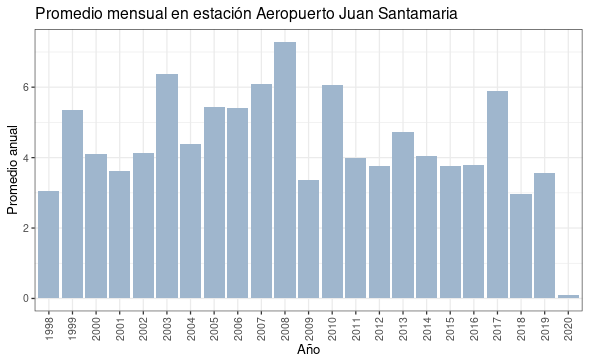

#### Santa Barbara

Precipitación anual media en la estación Santa Barbara

| Año | x |
| --- | --- |
| 2001 | 3.5267857 |
| 2002 | 5.4842105 |
| 2003 | 7.8000000 |
| 2004 | 6.4439628 |
| 2005 | 4.5387681 |
| 2006 | 6.8994220 |
| 2007 | 8.4119777 |
| 2008 | 9.5368590 |
| 2009 | 5.0744807 |
| 2010 | 9.2916000 |
| 2011 | 6.8360324 |
| 2012 | 8.3211268 |
| 2013 | 7.3102410 |
| 2014 | 6.4722527 |
| 2015 | 5.7923288 |
| 2016 | 6.7080357 |
| 2017 | 10.4969613 |
| 2018 | 6.3216438 |
| 2019 | 5.6827397 |
| 2020 | 0.7806452 |

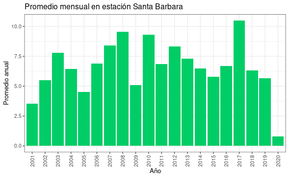

#### Naranjo

Precipitación anual media en la estación Naranjo

| Año | x |
| --- | --- |
| 2013 | 3.788235 |
| 2014 | 4.527671 |
| 2015 | 4.494118 |
| 2016 | 7.825547 |
| 2017 | 2.634587 |
| 2018 | 4.339726 |
| 2019 | 4.153289 |
| 2020 | 0.116129 |

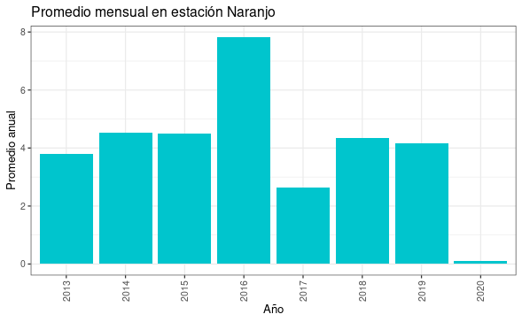

#### Número de días con precipitación en cada estación

### Datos sin normalizar

| Nombre_Base | n |
| --- | --- |
| metdata_Santamaria | 3702 |
| metdata_naranjitobello | 1285 |
| metdata_santabarbara | 3506 |

#### Como la estacion del aeropuerto y la de Santa Barbara tiene mas conteos hay que recortar apartir de cuanto la de Naranjo emepezo a tomar datos.

| Date | DV | VV | TN | TM | HR | PP | RAD_MEA | SUNSHINE | Nombre_Base | month |
| --- | --- | --- | --- | --- | --- | --- | --- | --- | --- | --- |
| 1998-12-01 | 3 | 3.6 | 19.16 | 21.4 | 81 | 2.4 | 8.1 | 11.58167 | metdata_Santamaria | Dec |
| 1999-01-01 | 3 | 4.5 | 17.76 | 22.6 | 73 | 0.0 | 15.4 | 11.55111 | metdata_Santamaria | Jan |
| 1999-02-01 | 3 | 8.2 | 19.39 | 22.4 | 64 | 0.0 | 18.2 | 11.70472 | metdata_Santamaria | Feb |
| 1999-03-01 | 4 | 3.2 | 16.94 | 21.7 | 63 | 0.0 | 23.4 | 11.93556 | metdata_Santamaria | Mar |
| 1999-04-01 | 3 | 5.4 | 19.37 | 23.5 | 59 | 0.0 | 25.5 | 12.22083 | metdata_Santamaria | Apr |
| 1999-05-01 | 3 | 2.2 | 17.82 | 21.0 | 88 | 21.6 | 17.3 | 12.48028 | metdata_Santamaria | May |

| Date | DV | VV | TN | TM | HR | PP | RAD_MEA | SUNSHINE | Nombre_Base | month |
| --- | --- | --- | --- | --- | --- | --- | --- | --- | --- | --- |
| 2013-11-01 | 3 | 2.8 | 16.28 | 20.9 | 85 | 11.3 | 22.7 | 11.76667 | metdata_Santamaria | Nov |
| 2013-12-01 | 3 | 4.5 | 19.34 | 22.3 | 63 | 0.0 | 16.8 | 11.58111 | metdata_Santamaria | Dec |
| 2014-01-01 | 4 | 7.1 | 20.71 | 23.2 | 62 | 0.0 | 19.9 | 11.55139 | metdata_Santamaria | Jan |
| 2014-02-01 | 4 | 5.7 | 15.45 | 21.9 | 55 | 0.0 | 23.6 | 11.70528 | metdata_Santamaria | Feb |
| 2014-03-01 | 3 | 5.9 | 16.65 | 23.2 | 56 | 0.0 | 26.6 | 11.93639 | metdata_Santamaria | Mar |
| 2014-04-01 | 4 | 6.8 | 18.74 | 24.1 | 45 | 0.0 | 28.5 | 12.22194 | metdata_Santamaria | Apr |

| Nombre_Base | n |
| --- | --- |
| metdata_Santamaria | 1003 |
| metdata_naranjitobello | 1278 |
| metdata_santabarbara | 1230 |

### 1.1. Estimación de la Evapotranspiración Potencial (ETP): estimada al menos por una metodología (método de Thornthwaite).

### cargar base de datos

#### Calcular el indice calorico mensual para cada mes

#### Calcular el indice calorico anual

##### Calcular el coeficiente de ajuste para cada mes

#### Calcular la evapotranspiracion potencial

| month | TM | SUNSHINE | days_per_month | ind.c.m | c.ajxm | Thornthwaite | Avg_PP |
| --- | --- | --- | --- | --- | --- | --- | --- |
| Jan | 21.63287 | 11.61174 | 31.00000 | 9.185913 | 0.9999000 | 82.19912 | 17.26818 |
| Feb | 21.85917 | 11.81189 | 28.23501 | 9.331788 | 0.9264132 | 78.13399 | 25.36190 |
| Mar | 22.36360 | 12.07534 | 31.00000 | 9.659741 | 1.0398212 | 92.76459 | 61.26667 |
| Apr | 22.58170 | 12.35172 | 30.00000 | 9.802730 | 1.0293099 | 94.04701 | 189.64762 |
| May | 22.08038 | 12.58473 | 31.00000 | 9.475132 | 1.0836848 | 93.69187 | 578.15238 |
| Jun | 21.89867 | 12.69856 | 30.00000 | 9.357329 | 1.0582130 | 89.64752 | 530.77143 |
| Jul | 21.89815 | 12.64057 | 31.00000 | 9.356995 | 1.0884935 | 92.20741 | 361.29524 |
| Aug | 21.68889 | 12.44103 | 31.00000 | 9.221948 | 1.0713107 | 88.63199 | 512.47143 |
| Sep | 21.26710 | 12.17627 | 30.00000 | 8.951788 | 1.0146894 | 79.98604 | 725.74762 |
| Oct | 21.09482 | 11.90149 | 31.00000 | 8.842228 | 1.0248502 | 79.18565 | 702.09048 |
| Nov | 21.24606 | 11.66648 | 30.00000 | 8.938381 | 0.9722065 | 76.45067 | 336.84091 |
| Dec | 21.55942 | 11.54890 | 31.00000 | 9.138730 | 0.9944889 | 81.07265 | 81.35909 |

#Cargar ETP

# 1.2. Balance de agua del suelo: Balance hidrológico climático (BHC)

| month | Avg_PP | Thornthwaite |
| --- | --- | --- |
| Jan | 17.26818 | 82.19912 |
| Feb | 25.36190 | 78.13399 |
| Mar | 61.26667 | 92.76459 |
| Apr | 189.64762 | 94.04701 |
| May | 578.15238 | 93.69187 |
| Jun | 530.77143 | 89.64752 |
| Jul | 361.29524 | 92.20741 |
| Aug | 512.47143 | 88.63199 |
| Sep | 725.74762 | 79.98604 |
| Oct | 702.09048 | 79.18565 |
| Nov | 336.84091 | 76.45067 |
| Dec | 81.35909 | 81.07265 |

### Calculo de Deficit de presión

#### Calcular almacenamiento

|  | month | Avg_PP | Thornthwaite | PP_ETP | Almacenamiento |
| --- | --- | --- | --- | --- | --- |
| 1 | Jan | 17.26818 | 82.19912 | -64.9309387 | 52.24064 |
| 2 | Feb | 25.36190 | 78.13399 | -52.7720869 | 30.81926 |
| 3 | Mar | 61.26667 | 92.76459 | -31.4979227 | 22.49202 |
| 4 | Apr | 189.64762 | 94.04701 | 95.6006118 | 100.00000 |
| 5 | May | 578.15238 | 93.69187 | 484.4605158 | 100.00000 |
| 6 | Jun | 530.77143 | 89.64752 | 441.1239063 | 100.00000 |
| 7 | Jul | 361.29524 | 92.20741 | 269.0878330 | 100.00000 |
| 8 | Aug | 512.47143 | 88.63199 | 423.8394366 | 100.00000 |
| 9 | Sep | 725.74762 | 79.98604 | 645.7615799 | 100.00000 |
| 10 | Oct | 702.09048 | 79.18565 | 622.9048300 | 100.00000 |

[output cut: 2 more lines]

### Cacular Cambio en el almacenamiento

|  | month | Avg_PP | Thornthwaite | PP_ETP | Almacenamiento | Cambio_almacena |
| --- | --- | --- | --- | --- | --- | --- |
| 1 | Jan | 17.26818 | 82.19912 | -64.9309387 | 52.24064 | -47.759357 |
| 2 | Feb | 25.36190 | 78.13399 | -52.7720869 | 30.81926 | -21.421380 |
| 3 | Mar | 61.26667 | 92.76459 | -31.4979227 | 22.49202 | -8.327241 |
| 4 | Apr | 189.64762 | 94.04701 | 95.6006118 | 100.00000 | 77.507977 |
| 5 | May | 578.15238 | 93.69187 | 484.4605158 | 100.00000 | 0.000000 |
| 6 | Jun | 530.77143 | 89.64752 | 441.1239063 | 100.00000 | 0.000000 |
| 7 | Jul | 361.29524 | 92.20741 | 269.0878330 | 100.00000 | 0.000000 |
| 8 | Aug | 512.47143 | 88.63199 | 423.8394366 | 100.00000 | 0.000000 |
| 9 | Sep | 725.74762 | 79.98604 | 645.7615799 | 100.00000 | 0.000000 |
| 10 | Oct | 702.09048 | 79.18565 | 622.9048300 | 100.00000 | 0.000000 |

[output cut: 2 more lines]

### Cacular Evapotranspiración Real (ETR)

|  | month | Avg_PP | Thornthwaite | PP_ETP | Almacenamiento | Cambio_almacena | ETR |
| --- | --- | --- | --- | --- | --- | --- | --- |
| 1 | Jan | 17.26818 | 82.19912 | -64.9309387 | 52.24064 | -47.759357 | 65.02754 |
| 2 | Feb | 25.36190 | 78.13399 | -52.7720869 | 30.81926 | -21.421380 | 46.78328 |
| 3 | Mar | 61.26667 | 92.76459 | -31.4979227 | 22.49202 | -8.327241 | 69.59391 |
| 4 | Apr | 189.64762 | 94.04701 | 95.6006118 | 100.00000 | 77.507977 | 94.04701 |
| 5 | May | 578.15238 | 93.69187 | 484.4605158 | 100.00000 | 0.000000 | 93.69187 |
| 6 | Jun | 530.77143 | 89.64752 | 441.1239063 | 100.00000 | 0.000000 | 89.64752 |
| 7 | Jul | 361.29524 | 92.20741 | 269.0878330 | 100.00000 | 0.000000 | 92.20741 |
| 8 | Aug | 512.47143 | 88.63199 | 423.8394366 | 100.00000 | 0.000000 | 88.63199 |
| 9 | Sep | 725.74762 | 79.98604 | 645.7615799 | 100.00000 | 0.000000 | 79.98604 |
| 10 | Oct | 702.09048 | 79.18565 | 622.9048300 | 100.00000 | 0.000000 | 79.18565 |

[output cut: 2 more lines]

### Calcular Deficit Hidrico

|  | month | Avg_PP | Thornthwaite | PP_ETP | Almacenamiento | Cambio_almacena | ETR | Deficit_H |
| --- | --- | --- | --- | --- | --- | --- | --- | --- |
| 1 | Jan | 17.26818 | 82.19912 | -64.9309387 | 52.24064 | -47.759357 | 65.02754 | 17.17158 |
| 2 | Feb | 25.36190 | 78.13399 | -52.7720869 | 30.81926 | -21.421380 | 46.78328 | 31.35071 |
| 3 | Mar | 61.26667 | 92.76459 | -31.4979227 | 22.49202 | -8.327241 | 69.59391 | 23.17068 |
| 4 | Apr | 189.64762 | 94.04701 | 95.6006118 | 100.00000 | 77.507977 | 94.04701 | 0.00000 |
| 5 | May | 578.15238 | 93.69187 | 484.4605158 | 100.00000 | 0.000000 | 93.69187 | 0.00000 |
| 6 | Jun | 530.77143 | 89.64752 | 441.1239063 | 100.00000 | 0.000000 | 89.64752 | 0.00000 |
| 7 | Jul | 361.29524 | 92.20741 | 269.0878330 | 100.00000 | 0.000000 | 92.20741 | 0.00000 |
| 8 | Aug | 512.47143 | 88.63199 | 423.8394366 | 100.00000 | 0.000000 | 88.63199 | 0.00000 |
| 9 | Sep | 725.74762 | 79.98604 | 645.7615799 | 100.00000 | 0.000000 | 79.98604 | 0.00000 |
| 10 | Oct | 702.09048 | 79.18565 | 622.9048300 | 100.00000 | 0.000000 | 79.18565 | 0.00000 |

[output cut: 2 more lines]

#### Calcular Exceso Hidrico

|  | month | Avg_PP | Thornthwaite | PP_ETP | Almacenamiento | Cambio_almacena | ETR | Deficit_H | Exceso |
| --- | --- | --- | --- | --- | --- | --- | --- | --- | --- |
| 1 | Jan | 17.26818 | 82.19912 | -64.9309387 | 52.24064 | -47.759357 | 65.02754 | 17.17158 | 0.0000000 |
| 2 | Feb | 25.36190 | 78.13399 | -52.7720869 | 30.81926 | -21.421380 | 46.78328 | 31.35071 | 0.0000000 |
| 3 | Mar | 61.26667 | 92.76459 | -31.4979227 | 22.49202 | -8.327241 | 69.59391 | 23.17068 | 0.0000000 |
| 4 | Apr | 189.64762 | 94.04701 | 95.6006118 | 100.00000 | 77.507977 | 94.04701 | 0.00000 | 18.0926346 |
| 5 | May | 578.15238 | 93.69187 | 484.4605158 | 100.00000 | 0.000000 | 93.69187 | 0.00000 | 484.4605158 |
| 6 | Jun | 530.77143 | 89.64752 | 441.1239063 | 100.00000 | 0.000000 | 89.64752 | 0.00000 | 441.1239063 |
| 7 | Jul | 361.29524 | 92.20741 | 269.0878330 | 100.00000 | 0.000000 | 92.20741 | 0.00000 | 269.0878330 |
| 8 | Aug | 512.47143 | 88.63199 | 423.8394366 | 100.00000 | 0.000000 | 88.63199 | 0.00000 | 423.8394366 |
| 9 | Sep | 725.74762 | 79.98604 | 645.7615799 | 100.00000 | 0.000000 | 79.98604 | 0.00000 | 645.7615799 |
| 10 | Oct | 702.09048 | 79.18565 | 622.9048300 | 100.00000 | 0.000000 | 79.18565 | 0.00000 | 622.9048300 |

[output cut: 2 more lines]

#### Calcular Saturación Hidrica

|  | month | Avg_PP | Thornthwaite | PP_ETP | Almacenamiento | Cambio_almacena | ETR | Deficit_H | Exceso | Saturación |
| --- | --- | --- | --- | --- | --- | --- | --- | --- | --- | --- |
| 1 | Jan | 17.26818 | 82.19912 | -64.9309387 | 52.24064 | -47.759357 | 65.02754 | 17.17158 | 0.0000000 | -17.1715820 |
| 2 | Feb | 25.36190 | 78.13399 | -52.7720869 | 30.81926 | -21.421380 | 46.78328 | 31.35071 | 0.0000000 | -31.3507070 |
| 3 | Mar | 61.26667 | 92.76459 | -31.4979227 | 22.49202 | -8.327241 | 69.59391 | 23.17068 | 0.0000000 | -23.1706821 |
| 4 | Apr | 189.64762 | 94.04701 | 95.6006118 | 100.00000 | 77.507977 | 94.04701 | 0.00000 | 18.0926346 | 18.0926346 |
| 5 | May | 578.15238 | 93.69187 | 484.4605158 | 100.00000 | 0.000000 | 93.69187 | 0.00000 | 484.4605158 | 484.4605158 |
| 6 | Jun | 530.77143 | 89.64752 | 441.1239063 | 100.00000 | 0.000000 | 89.64752 | 0.00000 | 441.1239063 | 441.1239063 |
| 7 | Jul | 361.29524 | 92.20741 | 269.0878330 | 100.00000 | 0.000000 | 92.20741 | 0.00000 | 269.0878330 | 269.0878330 |
| 8 | Aug | 512.47143 | 88.63199 | 423.8394366 | 100.00000 | 0.000000 | 88.63199 | 0.00000 | 423.8394366 | 423.8394366 |
| 9 | Sep | 725.74762 | 79.98604 | 645.7615799 | 100.00000 | 0.000000 | 79.98604 | 0.00000 | 645.7615799 | 645.7615799 |
| 10 | Oct | 702.09048 | 79.18565 | 622.9048300 | 100.00000 | 0.000000 | 79.18565 | 0.00000 | 622.9048300 | 622.9048300 |

[output cut: 2 more lines]

### Calcular anual

| month | Avg_PP | Thornthwaite | PP_ETP | Almacenamiento | Cambio_almacena | ETR | Deficit_H | Exceso | Saturación |
| --- | --- | --- | --- | --- | --- | --- | --- | --- | --- |
| Jan | 17.26818 | 82.19912 | -64.9309387 | 52.24064 | -4.775936e+01 | 65.02754 | 17.17158 | 0.0000000 | -17.1715820 |
| Feb | 25.36190 | 78.13399 | -52.7720869 | 30.81926 | -2.142138e+01 | 46.78328 | 31.35071 | 0.0000000 | -31.3507070 |
| Mar | 61.26667 | 92.76459 | -31.4979227 | 22.49202 | -8.327241e+00 | 69.59391 | 23.17068 | 0.0000000 | -23.1706821 |
| Apr | 189.64762 | 94.04701 | 95.6006118 | 100.00000 | 7.750798e+01 | 94.04701 | 0.00000 | 18.0926346 | 18.0926346 |
| May | 578.15238 | 93.69187 | 484.4605158 | 100.00000 | 0.000000e+00 | 93.69187 | 0.00000 | 484.4605158 | 484.4605158 |
| Jun | 530.77143 | 89.64752 | 441.1239063 | 100.00000 | 0.000000e+00 | 89.64752 | 0.00000 | 441.1239063 | 441.1239063 |
| Jul | 361.29524 | 92.20741 | 269.0878330 | 100.00000 | 0.000000e+00 | 92.20741 | 0.00000 | 269.0878330 | 269.0878330 |
| Aug | 512.47143 | 88.63199 | 423.8394366 | 100.00000 | 0.000000e+00 | 88.63199 | 0.00000 | 423.8394366 | 423.8394366 |
| Sep | 725.74762 | 79.98604 | 645.7615799 | 100.00000 | 0.000000e+00 | 79.98604 | 0.00000 | 645.7615799 | 645.7615799 |
| Oct | 702.09048 | 79.18565 | 622.9048300 | 100.00000 | 0.000000e+00 | 79.18565 | 0.00000 | 622.9048300 | 622.9048300 |

[output cut: 3 more lines]

#### Comprobar que cierra

#### Borra fila 13

#### Generar base de datos para el grafico

#### Generar base de datos, balance hidrologico

[figure not shown]

### 1.3. índice estandarizado de precipitación

#### Cargar bases de datos

```r
library(readr)
library(readxl)
metdata_Santamaria <- read_csv("metdata_Santamaria.csv")
temperatura_maxima <- read_excel("temperatura_maxima.xlsx",
    col_types = c("date", "numeric"))
```

### Agregar columna de temperatura maxima

|  | Date | DV | VV | TN | TM | HR | PP | RAD_MEA | SUNSHINE | TEMP_MAX |
| --- | --- | --- | --- | --- | --- | --- | --- | --- | --- | --- |
| 1 | 1998-11-04 | NA | NA | NA | NA | 87 | NA | 13.5 | 11.74417 | NA |
| 2 | 1998-11-05 | 6 | 1.7 | NA | 21.6 | 93 | 4.6 | 10.1 | 11.73667 | 26.8 |
| 3 | 1998-11-06 | 3 | 2.6 | 19.67 | 20.3 | 93 | 31.7 | 3.6 | 11.72944 | 23.5 |
| 4 | 1998-11-07 | 7 | 3.0 | 16.39 | 21.6 | 87 | 0.0 | 15.0 | 11.72222 | 28.6 |
| 5 | 1998-11-08 | 2 | 2.8 | 17.76 | 21.2 | 84 | 14.8 | 12.3 | 11.71500 | 29.1 |
| 6 | 1998-11-09 | 7 | 2.9 | 18.10 | 21.7 | 83 | 0.0 | 12.6 | 11.70750 | 27.8 |

### El data frame de temperatura maxima tiene más fechas, esto altera el promedio al agregar 0 en las variables de precipitación y temperatura minima por lo cual se va a corregir

|  | Date | DV | VV | TN | TM | HR | PP | RAD_MEA | SUNSHINE | TEMP_MAX |
| --- | --- | --- | --- | --- | --- | --- | --- | --- | --- | --- |
| 3 | 1998-11-06 | 3 | 2.6 | 19.67 | 20.3 | 93 | 31.7 | 3.6 | 11.72944 | 23.5 |
| 4 | 1998-11-07 | 7 | 3.0 | 16.39 | 21.6 | 87 | 0.0 | 15.0 | 11.72222 | 28.6 |
| 5 | 1998-11-08 | 2 | 2.8 | 17.76 | 21.2 | 84 | 14.8 | 12.3 | 11.71500 | 29.1 |
| 6 | 1998-11-09 | 7 | 2.9 | 18.10 | 21.7 | 83 | 0.0 | 12.6 | 11.70750 | 27.8 |
| 7 | 1998-11-10 | 3 | 4.0 | 17.38 | 22.7 | 73 | 0.0 | 20.4 | 11.70056 | 29.6 |
| 8 | 1998-11-11 | 3 | 5.3 | 17.82 | 22.8 | 69 | 0.0 | 18.3 | 11.69361 | 28.6 |

#### Agregar la columna mes y año

|  | Date | DV | VV | TN | TM | HR | PP | RAD_MEA | SUNSHINE | TEMP_MAX | month | year |
| --- | --- | --- | --- | --- | --- | --- | --- | --- | --- | --- | --- | --- |
| 3 | 1998-11-06 | 3 | 2.6 | 19.67 | 20.3 | 93 | 31.7 | 3.6 | 11.72944 | 23.5 | Nov | 1998 |
| 4 | 1998-11-07 | 7 | 3.0 | 16.39 | 21.6 | 87 | 0.0 | 15.0 | 11.72222 | 28.6 | Nov | 1998 |
| 5 | 1998-11-08 | 2 | 2.8 | 17.76 | 21.2 | 84 | 14.8 | 12.3 | 11.71500 | 29.1 | Nov | 1998 |
| 6 | 1998-11-09 | 7 | 2.9 | 18.10 | 21.7 | 83 | 0.0 | 12.6 | 11.70750 | 27.8 | Nov | 1998 |
| 7 | 1998-11-10 | 3 | 4.0 | 17.38 | 22.7 | 73 | 0.0 | 20.4 | 11.70056 | 29.6 | Nov | 1998 |
| 8 | 1998-11-11 | 3 | 5.3 | 17.82 | 22.8 | 69 | 0.0 | 18.3 | 11.69361 | 28.6 | Nov | 1998 |

### Generar data frame para el script de Cálculo del Índice Estandarizado de Precipitación-Evapotranspiración

| Mes | Año | Tmax | Pp | Tmin |
| --- | --- | --- | --- | --- |
| Jan | 1999 | 27.97419 | 0.01612903 | 17.54194 |
| Jan | 2000 | 27.25806 | 0.11935484 | 17.69839 |
| Jan | 2001 | 27.88065 | 0.37741935 | 17.76742 |
| Jan | 2002 | 28.41613 | 0.85483871 | 18.94935 |
| Jan | 2003 | 28.71774 | 0.00000000 | 19.48419 |
| Jan | 2004 | 28.45323 | 0.16129032 | 18.35548 |

### Cambiar formato de columna mes

| Mes | Año | Tmax | Pp | Tmin |
| --- | --- | --- | --- | --- |
| 1 | 1999 | 27.97419 | 0.01612903 | 17.54194 |
| 1 | 2000 | 27.25806 | 0.11935484 | 17.69839 |
| 1 | 2001 | 27.88065 | 0.37741935 | 17.76742 |
| 1 | 2002 | 28.41613 | 0.85483871 | 18.94935 |
| 1 | 2003 | 28.71774 | 0.00000000 | 19.48419 |
| 1 | 2004 | 28.45323 | 0.16129032 | 18.35548 |

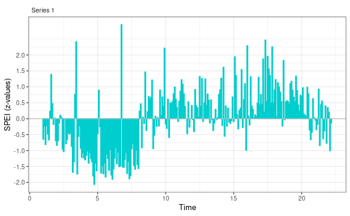

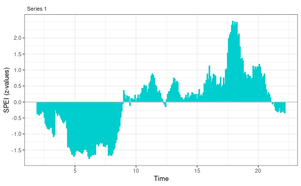

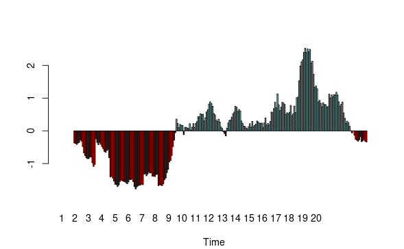

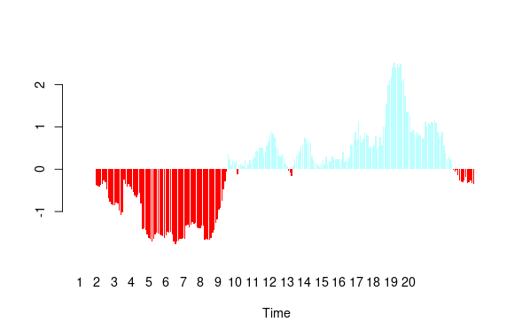

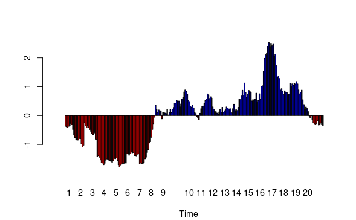

### Fuentes: Spínola, Manuel. 2023. “crcc: cambio climático Costa Rica.” January 30, 2023. https://mspinola-ciencia-de-datos.netlify.app/posts/2023-01-29-crcc/crcc.html.

### Fuentes: Spínola, Manuel. 2023. “crgeo: un paquete de R con datos geoespaciales de Costa Rica.” January 13, 2023. https://mspinola-ciencia-de-datos.netlify.app/posts/2023-01-09-crgeo/crgeo.html.